# Assessing injury on GOM cetaceans

# 5 Comparisons across species

In this section we present some summary analysis o the results across the 15 taxonomic units considered.

```r
#just some rounding for nicer visualization below
sumres$Nstart=round(sumres$Nstart)
sumres$Pexp=round(sumres$Pexp,3)
```

## 5.1 Initial population and proportion exposed

The population size and the proportion exposed are $a priori$ expected to be key determinants of injury, since the population size will have a direct impact on LCY and the proportion exposed should have a direct impact on all 3 measures.

```r
kable(sumres[, c(1, 2, 7, 3, 9)],caption = "Initial population size (N) and proportion exposed (pe or Pexp) for the different stocks considered.  The suffix o indicates old results from the MMIQT report and Schwacke et al. 2017",digits = c(0, 0, 0, 3, 3))
```

Initial population size (N) and proportion exposed (pe or Pexp) for the different stocks considered. The suffix o indicates old results from the MMIQT report and Schwacke et al. 2017

| Sp | No | Nstart | peo | Pexp |
| --- | --- | --- | --- | --- |
| Bwsp | 1167 | 3098 | 0.119 | 0.140 |
| Fatt | 1696 | 2152 | 0.150 | 0.145 |
| Ggri | 1848 | 3063 | 0.076 | 0.197 |
| Gmac | 1641 | 2065 | 0.057 | 0.120 |
| Kosp | 6690 | 2322 | 0.151 | 0.197 |
| Pele | 1696 | 5784 | 0.150 | 0.152 |
| Pmac | 1616 | 2561 | 0.161 | 0.191 |
| Satt | 33382 | 81233 | 0.196 | 0.155 |
| Sbre | 2414 | 4867 | 0.409 | 0.148 |
| Scly | 3228 | 9065 | 0.071 | 0.082 |
| Scoe | 2602 | 5011 | 0.132 | 0.247 |
| Sfro | NA | 48688 | 0.125 | 0.058 |
| Slon | 6621 | 16501 | 0.465 | 0.377 |
| Ttro | 8467 | 15791 | 0.099 | 0.206 |
| Ttrs | 63361 | 64897 | 0.125 | 0.177 |

The proportion exposed against the initial population size is shown here for the 15 taxonomic units

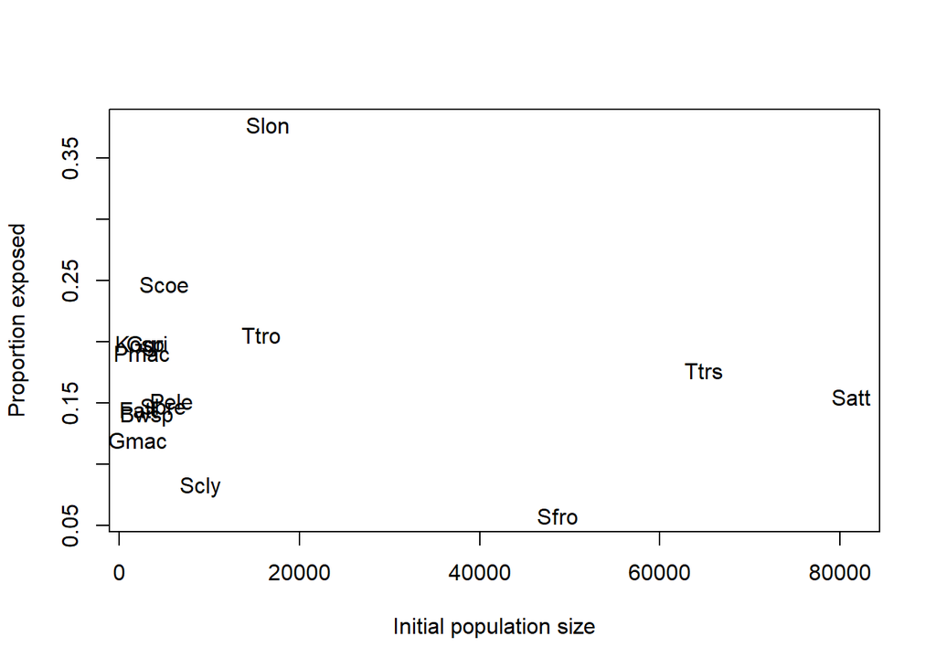

```r
plot(sumres[, c(7,9)],xlab="Initial population size",ylab="Proportion exposed",type="n")
text(x = sumres[, 7],y=sumres[, 9],labels = sumres[, 1])
```

*DELETE IMAGES BELOW AND REMOVE MMIQT RESULTS ABOVE?*

The image below illustrates that there is no clear relationship between the initial population size assumed before (DWH MMIQT 2015) and the one being currently considered. This was expected given the completely different way in which population sizes were obtained in this exercise (via a spatial model) and before (a coarser stratification approach).

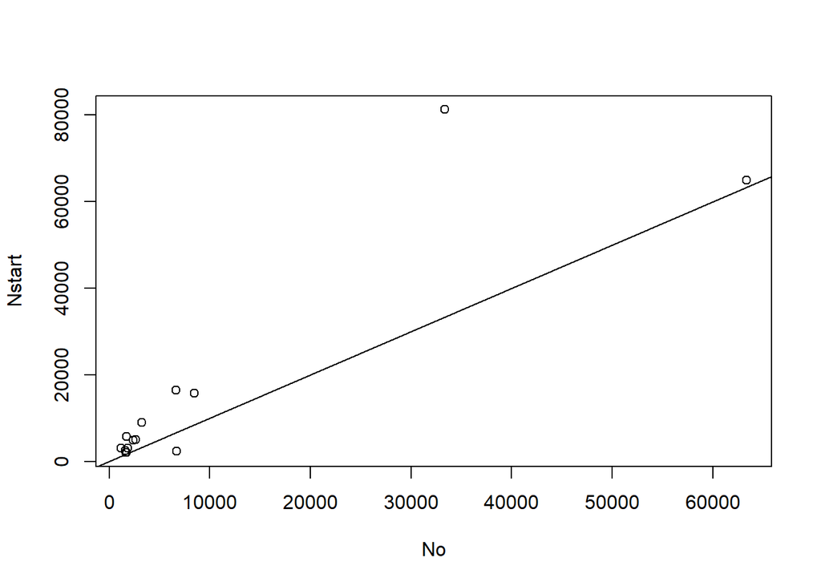

```r
with(sumres, plot(No,Nstart))
abline(0, 1)
```

The same happens for the proportion exposed, for the same reasons.

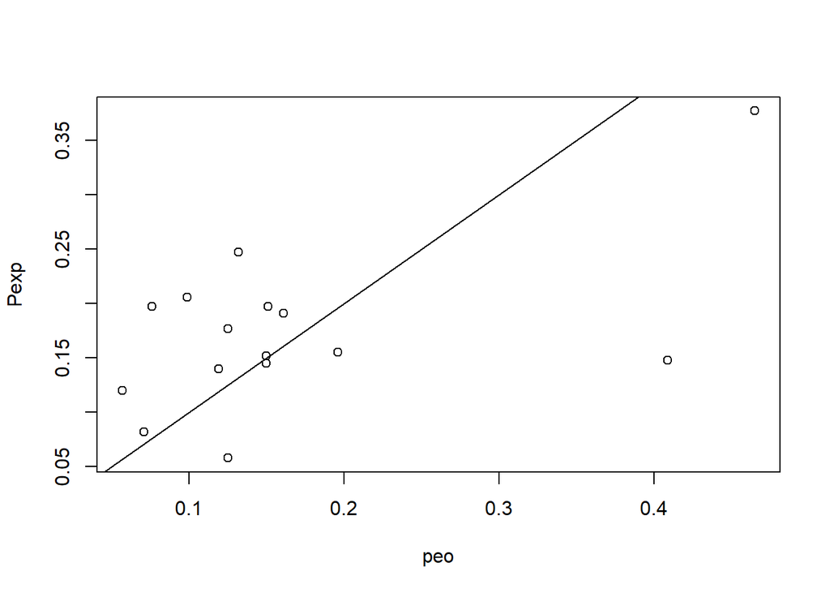

```r
with(sumres, plot(peo, Pexp))
abline(0,1)
```

This illustrates how direct comparisons of results between here and the previous DWH MMIQT (2015) results is far from straightforward, since not only the model has changed, but the inputs to the model have also changed.

*DELETE IMAGES ABOVE AND REMOVE MMIQT RESULTS ABOVE?*

## 5.2 Injury metrics

### 5.2.1 Means and Medians

In the following table we present the means and medians of the injury metrics for the current simulations, while the previous DWH MMIQT (2015) results are also shown for comparison:

```r
sumres$MPD <- -(sumres$MPD/100)
kable(sumres[, c(1, 4, 10, 13, 5, 11, 6, 12)],caption = "Injury results for the different stocks considered. The suffix o indicates old results MMIQT, med means median",digits = c(0, 0, 0, 0, 3, 3, 1, 1))
```

Injury results for the different stocks considered. The suffix o indicates old results MMIQT, med means median

| Sp | LCYo | LCY | LCYmed | MPDo | MPD | YTRo | YTR |
| --- | --- | --- | --- | --- | --- | --- | --- |
| Bwsp | 7838 | 1321 | 1207 | -0.06 | -0.038 | 10 | 1.6 |
| Fatt | 2501 | 1250 | 1122 | -0.07 | -0.042 | 29 | 2.3 |
| Ggri | 6258 | 2449 | 2264 | -0.03 | -0.057 | NA | 7.3 |
| Gmac | 5304 | 1058 | 964 | -0.03 | -0.035 | NA | 1.2 |
| Kosp | 49100 | 1429 | 1294 | -0.06 | -0.052 | 11 | 4.9 |
| Pele | 14887 | 3072 | 2761 | -0.07 | -0.042 | 29 | 2.1 |
| Pmac | 13197 | 2549 | 2356 | -0.07 | -0.064 | 21 | 9.7 |
| Satt | 363780 | 33810 | 31372 | -0.09 | -0.035 | 39 | 0.6 |
| Sbre | 50464 | 2434 | 2232 | -0.17 | -0.040 | 54 | 1.6 |
| Scly | 12167 | 1902 | 1726 | -0.03 | -0.018 | NA | 0.0 |
| Scoe | 18647 | 3715 | 3387 | -0.06 | -0.059 | 14 | 7.1 |
| Sfro | NA | 7509 | 6961 | NA | -0.013 | NA | 0.0 |
| Slon | 188713 | 17715 | 15255 | -0.23 | -0.089 | 105 | 11.2 |
| Ttro | 37668 | 11370 | 10537 | -0.04 | -0.057 | NA | 6.6 |
| Ttrs | 359996 | 35190 | 32584 | -0.03 | -0.042 | NA | 2.4 |

### 5.2.2 Precision

In this following table we present also the 95% confidence intervals for our current estimates of injury. Note this corresponds to the results in table 3 in the main paper.

```r
kable(injuryCI, caption = "Median injury results for the different stocks considered and respective 95% confidence intervals by the percentile method",digits = c(0, 0, 0, 0, 3, 3, 3, 1, 1, 1))
```

Median injury results for the different stocks considered and respective 95% confidence intervals by the percentile method

| Sp | LCYmed | LCYl | LCYu | MPDmed | MPDl | MPDu | YTRmed | YTRl | YTRu |
| --- | --- | --- | --- | --- | --- | --- | --- | --- | --- |
| Bwsp | 1207 | 445 | 2899 | 3.683 | 1.386 | 6.951 | 0 | 0 | 11 |
| Fatt | 1122 | 437 | 2809 | 4.186 | 1.939 | 6.642 | 0 | 0 | 13 |
| Ggri | 2264 | 978 | 5049 | 5.623 | 2.569 | 9.494 | 8 | 0 | 18 |
| Gmac | 964 | 385 | 2291 | 3.435 | 1.486 | 6.216 | 0 | 0 | 12 |
| Kosp | 1294 | 519 | 3112 | 5.114 | 2.315 | 8.492 | 5 | 0 | 14 |
| Pele | 2761 | 1081 | 6767 | 4.140 | 1.925 | 6.601 | 0 | 0 | 12 |
| Pmac | 2356 | 996 | 5240 | 6.344 | 2.672 | 10.189 | 11 | 0 | 21 |
| Satt | 31372 | 12884 | 67606 | 3.433 | 1.563 | 5.615 | 0 | 0 | 9 |
| Sbre | 2232 | 901 | 5207 | 3.995 | 1.836 | 6.349 | 0 | 0 | 11 |
| Scly | 1726 | 664 | 4067 | 1.734 | 0.747 | 3.261 | 0 | 0 | 0 |
| Scoe | 3387 | 1369 | 7897 | 5.673 | 2.479 | 10.426 | 8 | 0 | 17 |
| Sfro | 6961 | 2722 | 15509 | 1.264 | 0.542 | 2.280 | 0 | 0 | 0 |
| Slon | 15255 | 5302 | 44903 | 8.363 | 3.277 | 17.716 | 12 | 0 | 21 |
| Ttro | 10537 | 4597 | 23220 | 5.610 | 2.546 | 9.125 | 8 | 0 | 16 |
| Ttrs | 32584 | 13377 | 71967 | 4.152 | 1.859 | 6.758 | 0 | 0 | 13 |

Producing the values that are used in table 3 of the paper

```r
Table3LCY <-  paste0(round(injuryCI$LCYmed,0), " (",round(injuryCI$LCYl,0),", ",round(injuryCI$LCYu),") ")
Table3MPD <-  paste0(round(injuryCI$MPDmed,1), " (",round(injuryCI$MPDl,1),", ",round(injuryCI$MPDu,1), ") ")
Table3YTR <-  paste0(round(injuryCI$YTRmed,1), " (",round(injuryCI$YTRl,1)," ,",round(injuryCI$YTRu,1),")")
# IMPORTANT
# note removing row 16, Ttru, not for the pelagic paper
# These are outputed as 3 separate tables as
# that facilitates copy-pasting into
# the main paper word document
write.table(Table3LCY[-16],"Table3LCY.txt",sep="\t",row.names = FALSE,quote = FALSE,col.names = FALSE)
write.table(Table3MPD[-16],"Table3MPD.txt",sep="\t",row.names = FALSE,quote = FALSE,col.names = FALSE)
write.table(Table3YTR[-16],"Table3YTR.txt",sep="\t",row.names = FALSE,quote = FALSE,col.names = FALSE)
```

```r
#creating output tables for others to use
write.table(injuryCI,"injuryCI.txt")
write.table(sumres,"sumres.txt")
```

# 6 Discussion (work in progress)

To facilitate the discussion of the results obtained we present below explicitly comparisons between the previous values of injury (DWH MMIQT , 2015) and the current values for injury we are estimating.

We present such comparisons first for LCY

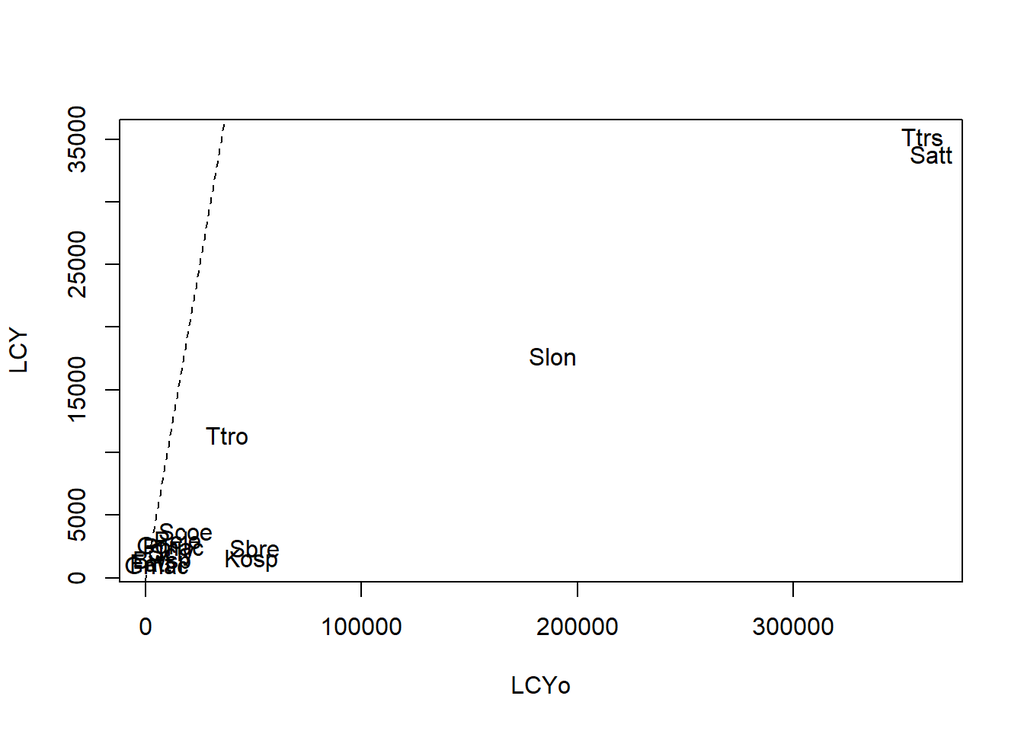

```r
with(sumres,plot(LCYo,LCY,type="n"))
with(sumres,text(LCYo,LCY,Sp))
abline(0,1,lty=2)
```

```r
#text(70000,2000,"Kogia")
#text(75000,15000,"Shelf dolphins")
#text(120000,3000,"rough-toothed dolphins")
#text(46000,36000,"BB BND")
```

followed by MPD

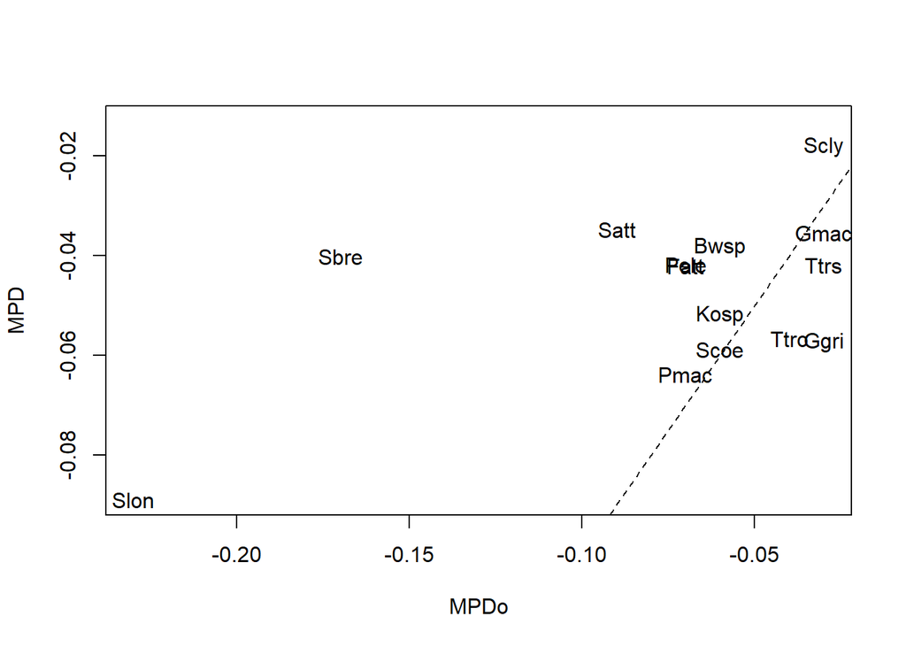

```r
with(sumres,plot(MPDo,MPD,type="n"))
with(sumres,text(MPDo,MPD,Sp))
abline(0, 1, lty = 2)
```

and finally YTR

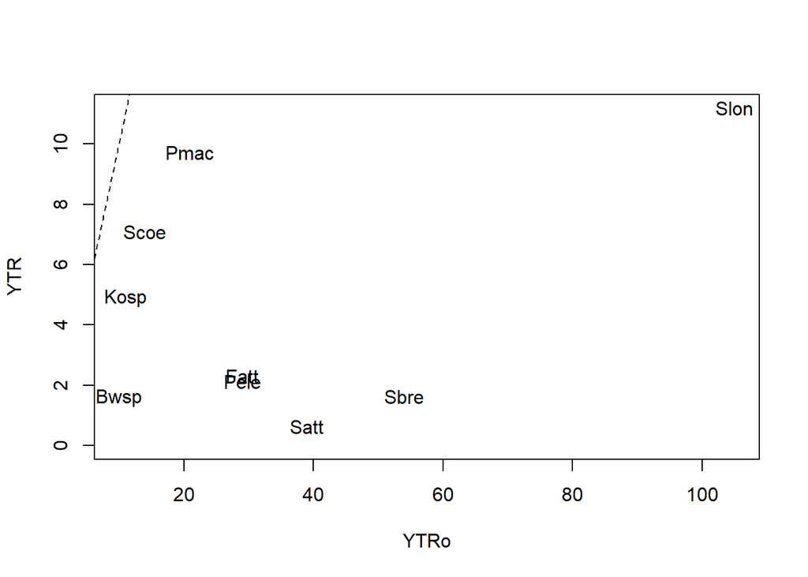

```r
with(sumres,plot(YTRo,YTR,type="n"))
with(sumres,text(YTRo,YTR,Sp))
abline(0, 1, lty = 2)
```

We also present the values of the injury metrics as a function of the proportion exposed (note that similar plots against other quantities might be helpful to interpret the results)

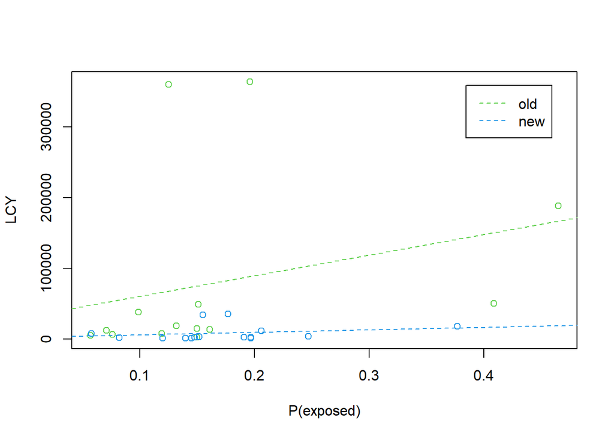

```r
#LCY
plot(c(sumres$peo,sumres$Pexp), c(sumres$LCYo,sumres$LCY), type="n",col=3, xlab="P(exposed)",ylab="LCY")
points(sumres$peo, sumres$LCYo, col=3)
abline(lm(sumres$LCYo~sumres$peo),col=3,lty=2)
points(sumres$Pexp, sumres$LCY,col=4)
abline(lm(sumres$LCY~sumres$Pexp),col=4,lty=2)
legend("topright",col=3:4,lty=2,c("old","new"),inset=0.05)
```

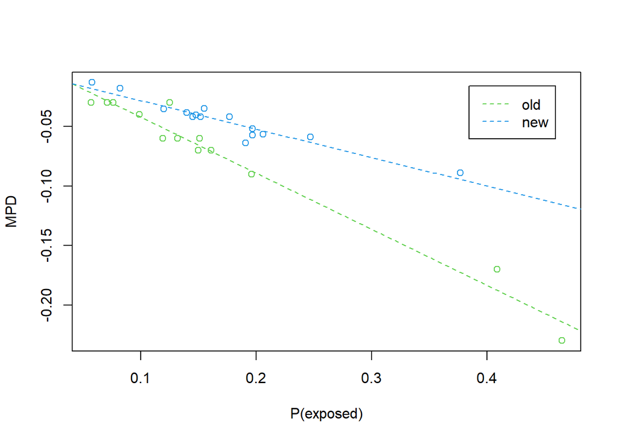

```r
#MPD
plot(c(sumres$peo,sumres$Pexp), c(sumres$MPDo,sumres$MPD), type="n",col=3, xlab="P(exposed)",ylab="MPD")
points(sumres$peo, sumres$MPDo, col=3)
abline(lm(sumres$MPDo~sumres$peo),col=3,lty=2)
points(sumres$Pexp, sumres$MPD,col=4)
abline(lm(sumres$MPD~sumres$Pexp),col=4,lty=2)
legend("topright",col=3:4,lty=2,c("old","new"),inset=0.05)
```

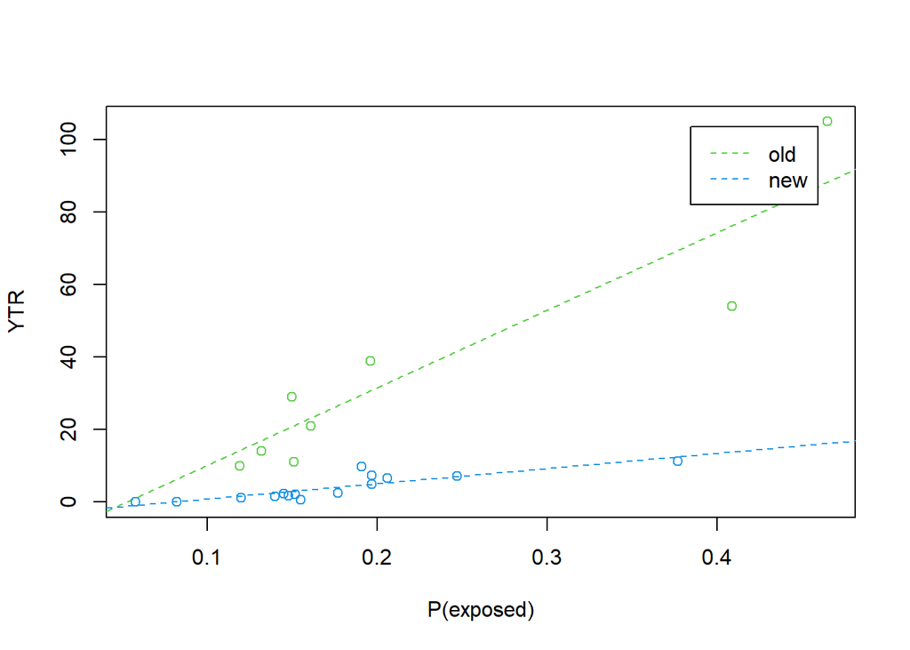

```r
#YTR
plot(c(sumres$peo,sumres$Pexp), c(sumres$YTRo,sumres$YTR), type="n",col=3, xlab="P(exposed)",ylab="YTR")
points(sumres$peo, sumres$YTRo, col=3)
abline(lm(sumres$YTRo~sumres$peo),col=3,lty=2)
points(sumres$Pexp, sumres$YTR,col=4)
abline(lm(sumres$YTR~sumres$Pexp),col=4,lty=2)
legend("topright",col=3:4,lty=2,c("old","new"),inset=0.05)
```

## 6.1 Explaining injury metrics across species

### 6.1.1 LCY

As noted above, one can anticipate that LCY would be strongly dependent on the initial population size and the proportion exposed. Therefore, we fit a linear model, treating species as sampling units, to explain LCY as a function of these two quantities. The summary of the corresponding linear model follows. Then we present a plot representing the observed values of LCY and those obtained by predicting from fitting a linear model of LCY as explained by initial population size and the proportion exposed.

```r
lmLCY <- lm(LCY ~ Pexp + Nstart, data = sumres)
summary(lmLCY)
```

```
##
## Call:
## lm(formula = LCY ~ Pexp + Nstart, data = sumres)
##
## Residuals:
##     Min      1Q  Median      3Q     Max
## -7835.4 -1189.7   855.8  1477.7  6430.2
##
## Coefficients:
##                Estimate  Std. Error t value     Pr(>|t|)
## (Intercept) -8585.80860  2457.09226  -3.494     0.004428 **
## Pexp        54656.60562 12278.22337   4.452     0.000791 ***
## Nstart          0.42640     0.03567  11.952 0.0000000505 ***
## ---
## Signif. codes:  0 '***' 0.001 '**' 0.01 '*' 0.05 '.' 0.1 ' ' 1
##
## Residual standard error: 3380 on 12 degrees of freedom
## Multiple R-squared:  0.9263, Adjusted R-squared:  0.9141
## F-statistic: 75.45 on 2 and 12 DF,  p-value: 0.0000001598
```

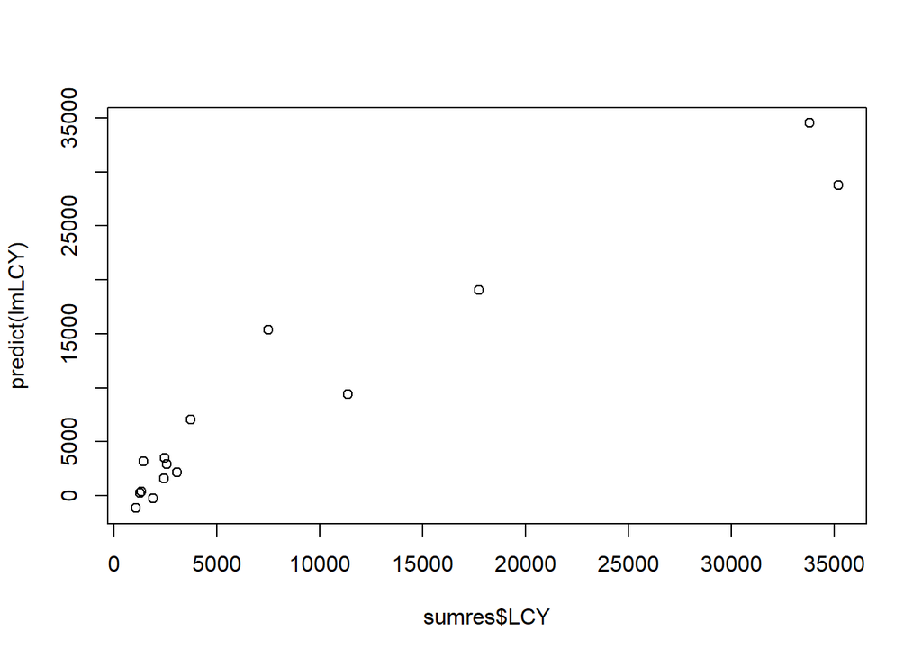

```r
plot(sumres$LCY, predict(lmLCY))
```

The LCY is very well explained by these two variable alone. A bit surprisingly, adding the gestation duration (that scales survival across species) does not even seem to help in explaining the injury

```r
lmLCY2 <- lm(LCY ~ Pexp + Nstart + inputs$gd, data = sumres)
summary(lmLCY2)
```

```
##
## Call:
## lm(formula = LCY ~ Pexp + Nstart + inputs$gd, data = sumres)
##
## Residuals:
##     Min      1Q  Median      3Q     Max
## -7666.8 -1329.1   628.1  1565.4  6130.3
##
## Coefficients:
##                 Estimate   Std. Error t value    Pr(>|t|)
## (Intercept) -13896.68340   9907.08218  -1.403      0.1883
## Pexp         56431.54254  13047.43272   4.325      0.0012 **
## Nstart           0.43441      0.03949  11.000 0.000000283 ***
## inputs$gd       12.73743     22.97221   0.554      0.5904
## ---
## Signif. codes:  0 '***' 0.001 '**' 0.01 '*' 0.05 '.' 0.1 ' ' 1
##
## Residual standard error: 3482 on 11 degrees of freedom
## Multiple R-squared:  0.9283, Adjusted R-squared:  0.9088
## F-statistic:  47.5 on 3 and 11 DF,  p-value: 0.000001384
```

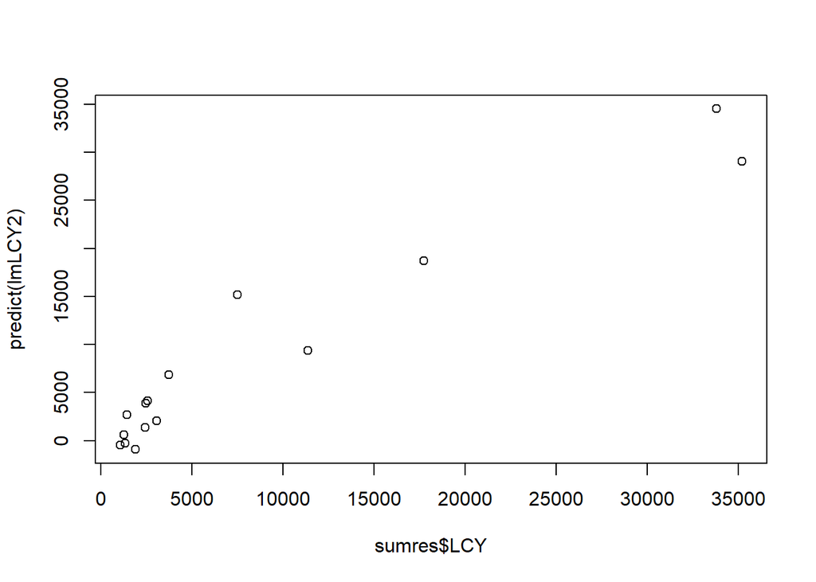

```r
plot(sumres$LCY, predict(lmLCY2))
```

```r
lmLCY3 <- lm(LCY ~ Pexp + Nstart + inputs$sr, data = sumres)
summary(lmLCY3)
```

```
##
## Call:
## lm(formula = LCY ~ Pexp + Nstart + inputs$sr, data = sumres)
##
## Residuals:
##     Min      1Q  Median      3Q     Max
## -7180.1 -1431.1  -169.7  1139.2  6334.6
##
## Coefficients:
##                 Estimate   Std. Error t value  Pr(>|t|)
## (Intercept)  46259.41927  63675.22121   0.726  0.482712
## Pexp         57305.30970  12786.55505   4.482  0.000929 ***
## Nstart           0.45317      0.04759   9.522 0.0000012 ***
## inputs$sr   -64560.21571  74897.25910  -0.862  0.407095
## ---
## Signif. codes:  0 '***' 0.001 '**' 0.01 '*' 0.05 '.' 0.1 ' ' 1
##
## Residual standard error: 3417 on 11 degrees of freedom
## Multiple R-squared:  0.931,  Adjusted R-squared:  0.9122
## F-statistic: 49.47 on 3 and 11 DF,  p-value: 0.000001125
```

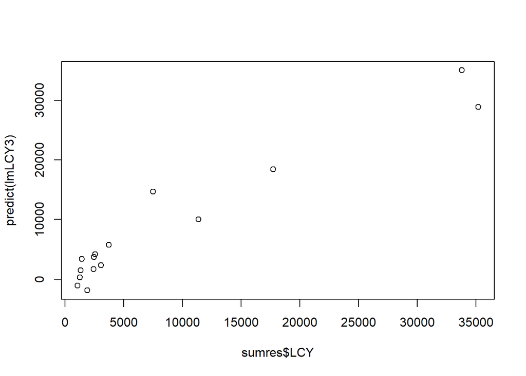

```r
plot(sumres$LCY, predict(lmLCY3))
```

We note that, when compared to the earlier assessments, the injury seems now considerably less than before. A large part of this was a bug in the calculation in the MMIQT values for LCY, but a part of it might be due to the modeling, and the many changes implemented from then to now.

### 6.1.2 YTR

Same idea for YTR, checking what determines that

```r
lmYTR <- lm(YTR ~ Pexp + Nstart + inputs$gd + inputs$sr, data = sumres)
summary(lmYTR)
```

```
##
## Call:
## lm(formula = YTR ~ Pexp + Nstart + inputs$gd + inputs$sr, data = sumres)
##
## Residuals:
##     Min      1Q  Median      3Q     Max
## -2.4070 -0.9508 -0.1701  1.0488  2.2652
##
## Coefficients:
##                 Estimate   Std. Error t value  Pr(>|t|)
## (Intercept) -10.39548158  35.50526953  -0.293    0.7757
## Pexp         44.06259754   6.10885365   7.213 0.0000288 ***
## Nstart       -0.00001320   0.00002246  -0.588    0.5697
## inputs$gd     0.02442470   0.01173963   2.081    0.0641 .
## inputs$sr    -2.76769050  39.00546788  -0.071    0.9448
## ---
## Signif. codes:  0 '***' 0.001 '**' 0.01 '*' 0.05 '.' 0.1 ' ' 1
##
## Residual standard error: 1.612 on 10 degrees of freedom
## Multiple R-squared:  0.8587, Adjusted R-squared:  0.8022
## F-statistic:  15.2 on 4 and 10 DF,  p-value: 0.0002979
```

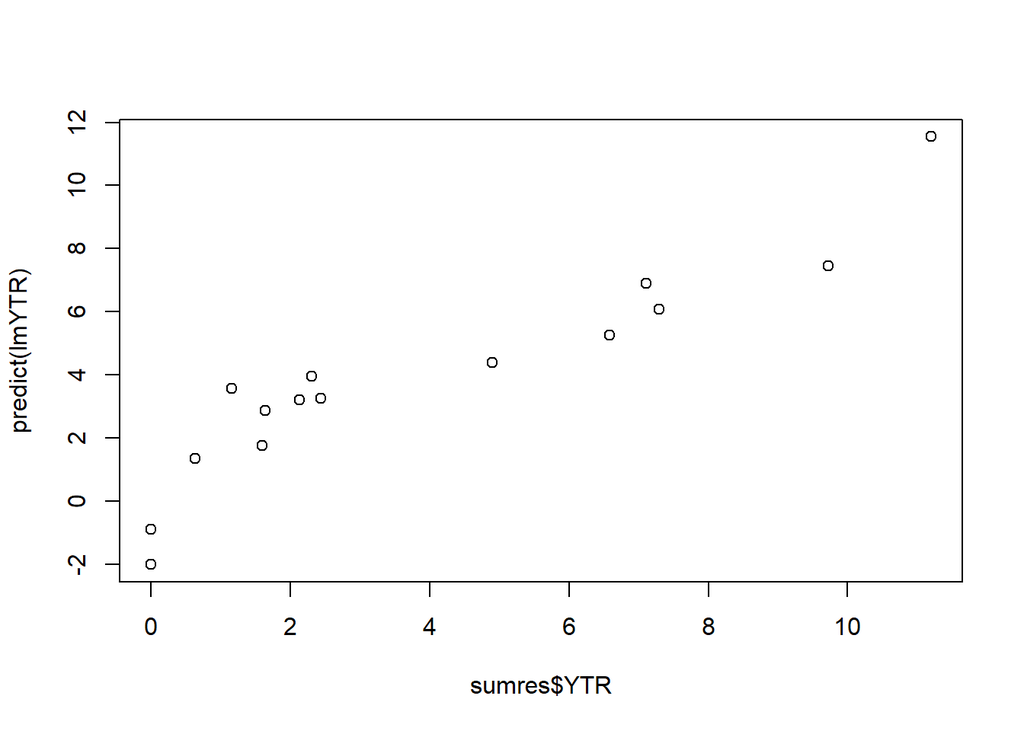

```r
plot(sumres$YTR, predict(lmYTR))
```

removing initial population size and survival reduction just to check if it helps

```r
lmYTR <- lm(YTR ~ Pexp + inputs$gd, data = sumres)
summary(lmYTR)
```

```
##
## Call:
## lm(formula = YTR ~ Pexp + inputs$gd, data = sumres)
##
## Residuals:
##    Min     1Q Median     3Q    Max
## -2.364 -1.229  0.256  1.220  2.177
##
## Coefficients:
##               Estimate Std. Error t value   Pr(>|t|)
## (Intercept) -14.465792   3.864204  -3.744     0.0028 **
## Pexp         44.996205   5.546928   8.112 0.00000326 ***
## inputs$gd     0.027785   0.009304   2.986     0.0113 *
## ---
## Signif. codes:  0 '***' 0.001 '**' 0.01 '*' 0.05 '.' 0.1 ' ' 1
##
## Residual standard error: 1.515 on 12 degrees of freedom
## Multiple R-squared:  0.8502, Adjusted R-squared:  0.8253
## F-statistic: 34.06 on 2 and 12 DF,  p-value: 0.00001129
```

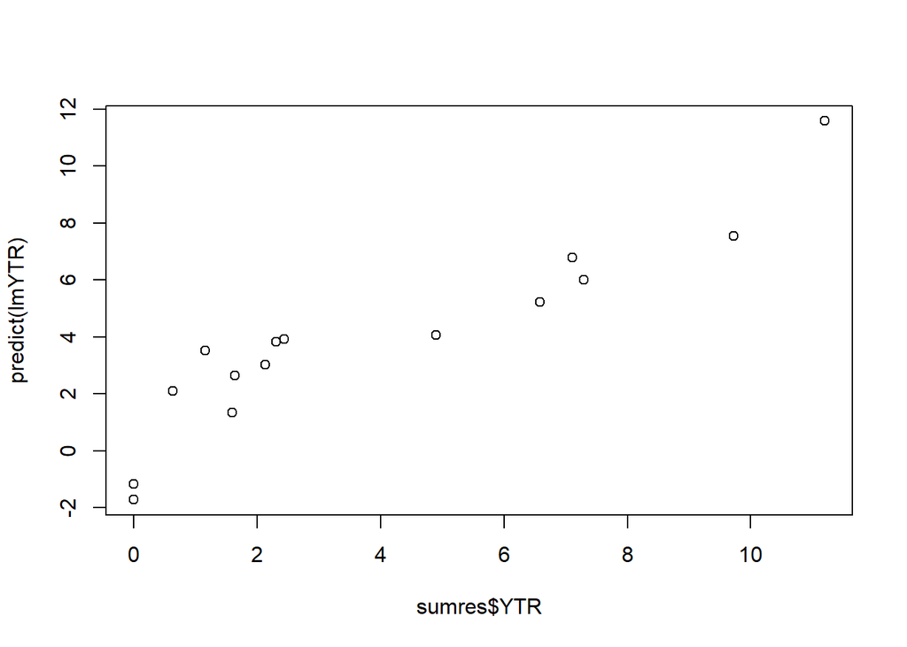

```r
plot(sumres$YTR, predict(lmYTR))
```

### 6.1.3 MPD

```r
lmMPD <- lm(MPD ~ Pexp + Nstart + inputs$gd + inputs$sr, data = sumres)
summary(lmMPD)
```

```
##
## Call:
## lm(formula = MPD ~ Pexp + Nstart + inputs$gd + inputs$sr, data = sumres)
##
## Residuals:
##        Min         1Q     Median         3Q        Max
## -0.0020813 -0.0012134  0.0003349  0.0006506  0.0033774
##
## Coefficients:
##                    Estimate      Std. Error t value         Pr(>|t|)
## (Intercept) -0.151552315891  0.037436101351  -4.048         0.002330 **
## Pexp        -0.251281070185  0.006441062618 -39.012 0.00000000000292 ***
## Nstart      -0.000000002801  0.000000023684  -0.118         0.908194
## inputs$gd   -0.000066147743  0.000012378054  -5.344         0.000326 ***
## inputs$sr    0.202300458589  0.041126645935   4.919         0.000606 ***
## ---
## Signif. codes:  0 '***' 0.001 '**' 0.01 '*' 0.05 '.' 0.1 ' ' 1
##
## Residual standard error: 0.0017 on 10 degrees of freedom
## Multiple R-squared:  0.9941, Adjusted R-squared:  0.9917
## F-statistic: 418.1 on 4 and 10 DF,  p-value: 0.0000000000443
```

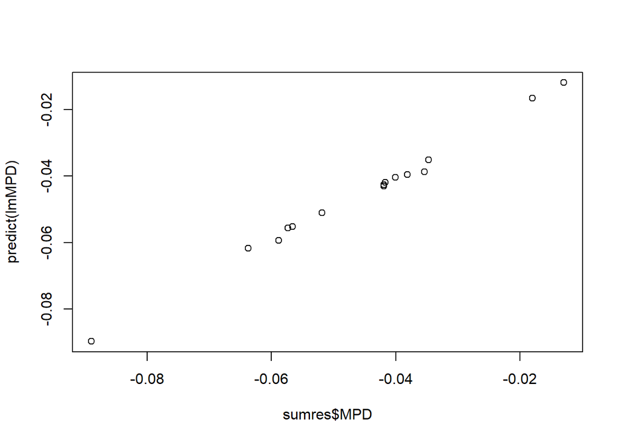

```r
plot(sumres$MPD, predict(lmMPD))
```

removing initial population size just to check if it helps

```r
lmMPD <- lm(MPD ~ Pexp + inputs$gd + inputs$sr, data = sumres)
summary(lmMPD)
```

```
##
## Call:
## lm(formula = MPD ~ Pexp + inputs$gd + inputs$sr, data = sumres)
##
## Residuals:
##        Min         1Q     Median         3Q        Max
## -0.0021149 -0.0011719  0.0002501  0.0006172  0.0034033
##
## Coefficients:
##                Estimate  Std. Error t value          Pr(>|t|)
## (Intercept) -0.14920867  0.03030463  -4.924          0.000454 ***
## Pexp        -0.25108419  0.00593682 -42.293 0.000000000000157 ***
## inputs$gd   -0.00006611  0.00001181  -5.600          0.000160 ***
## inputs$sr    0.19947520  0.03194222   6.245 0.000063054262260 ***
## ---
## Signif. codes:  0 '***' 0.001 '**' 0.01 '*' 0.05 '.' 0.1 ' ' 1
##
## Residual standard error: 0.001622 on 11 degrees of freedom
## Multiple R-squared:  0.994,  Adjusted R-squared:  0.9924
## F-statistic: 612.3 on 3 and 11 DF,  p-value: 0.000000000001623
```

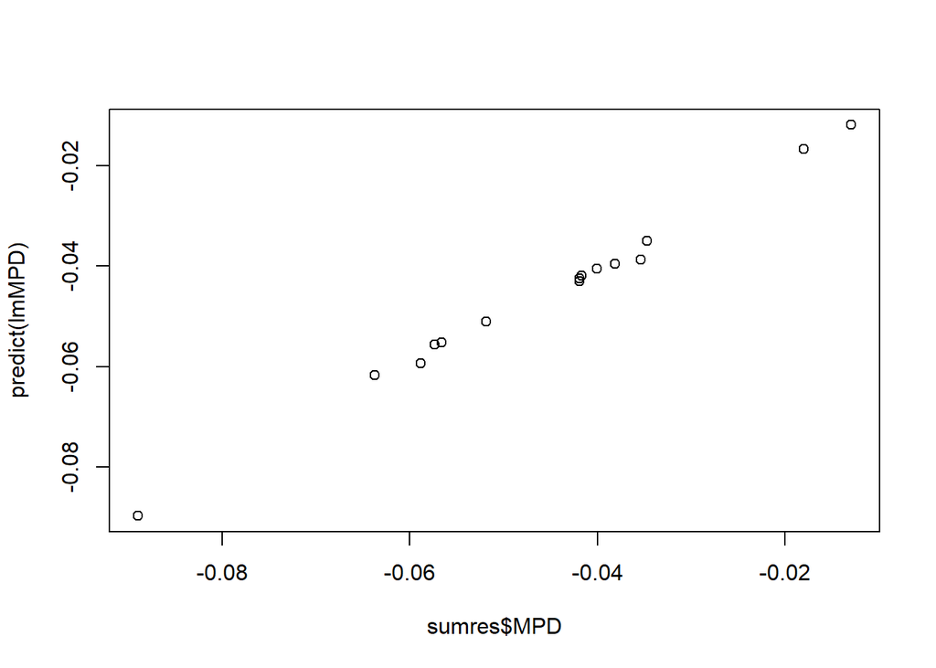

```r
plot(sumres$MPD, predict(lmMPD))
```

## 6.2 Species by species discussion

Here we compare the results for each of the species with those obtained before, trying to shed light on what the differences found might be due to.

To do so we show again the before and after key values for each species.

### 6.2.1 Bwsp beaked whales Beaked whales spp

We observe the following changes in injury and in key quantities that might affect the injury (initial population size and the proportion of the population exposed):

- lost cetacean years came down from 7838 to 1321
- maximum proportional decrease came down from -0.06 to -0.038
- years to recovery came down from 10 to 1.6
- The assumed initial population size changed from 1167 to 3098
- The proportion of the population exposed before was 0.119 and it is now 0.14.

### 6.2.2 Fatt pygmy killer whale *Feresa attenuata*

We observe the following changes in injury and in key quantities that might affect the injury (initial population size and the proportion of the population exposed):

- lost cetacean years came down from 2501 to 1250
- maximum proportional decrease came down from -0.07 to -0.042
- years to recovery came down from 29 to 2.3
- The assumed initial population size changed from 1696 to 2152
- The proportion of the population exposed before was 0.15 and it is now 0.145.

### 6.2.3 Ggri Risso’s dolphin *Grampus griseus*

We observe the following changes in injury and in key quantities that might affect the injury (initial population size and the proportion of the population exposed):

- lost cetacean years came down from 6258 to 2449
- maximum proportional decrease came down from -0.03 to -0.057
- years to recovery came down from NA to 7.3
- The assumed initial population size changed from 1848 to 3063
- The proportion of the population exposed before was 0.076 and it is now 0.197.

### 6.2.4 Gmac short-finned pilot whale *Globicephala macrorhynchus*

We observe the following changes in injury and in key quantities that might affect the injury (initial population size and the proportion of the population exposed):

- lost cetacean years came down from 5304 to 1058
- maximum proportional decrease came down from -0.03 to -0.035
- years to recovery came down from NA to 1.2
- The assumed initial population size changed from 1641 to 2065
- The proportion of the population exposed before was 0.057 and it is now 0.12.

### 6.2.5 Kosp kogia *Kogia* sp.

We observe the following changes in injury and in key quantities that might affect the injury (initial population size and the proportion of the population exposed):

- lost cetacean years came down from 49100 to 1429
- maximum proportional decrease came down from -0.06 to -0.052
- years to recovery came down from 11 to 4.9
- The assumed initial population size changed from 6690 to 2322
- The proportion of the population exposed before was 0.151 and it is now 0.197.

### 6.2.6 Pele melon-headed whale *Peponocephala electra*

We observe the following changes in injury and in key quantities that might affect the injury (initial population size and the proportion of the population exposed):

- lost cetacean years came down from 14887 to 3072
- maximum proportional decrease came down from -0.07 to -0.042
- years to recovery came down from 29 to 2.1
- The assumed initial population size changed from 1696 to 5784
- The proportion of the population exposed before was 0.15 and it is now 0.152.

### 6.2.7 Pmac sperm whale *Physeter macrocephalus*

We observe the following changes in injury and in key quantities that might affect the injury (initial population size and the proportion of the population exposed):

- lost cetacean years came down from 13197 to 2549
- maximum proportional decrease came down from -0.07 to -0.064
- years to recovery came down from 21 to 9.7
- The assumed initial population size changed from 1616 to 2561
- The proportion of the population exposed before was 0.161 and it is now 0.191.

For Pmac the the lost cetacean years came down from 13197 to 2549, but in fact the true value bug apart was 5637 (cf. GOMOSES 2020 poster). Therefore we would expect a decrease of the LCY by more than 50% just due to the bug (in the specific case of the sperm whale: 57.286 %).

### 6.2.8 Satt pantropical spotted dolphin *Stenella attenuata*

We observe the following changes in injury and in key quantities that might affect the injury (initial population size and the proportion of the population exposed):

- lost cetacean years came down from 363780 to 33810
- maximum proportional decrease came down from -0.09 to -0.035
- years to recovery came down from 39 to 0.6
- The assumed initial population size changed from 33382 to 81233
- The proportion of the population exposed before was 0.196 and it is now 0.155.

While a drop in the LCY can be explained by the already mentioned bug in the LCY calculation, and the reduction in the proportion exposed is also relevant (before it was 0.196, now it is 0.155, these do not seem enough to justify the observed differences, namely in the YTR.

### 6.2.9 Sbre rough-toothed dolphin *Steno bredanensis*

We observe the following changes in injury and in key quantities that might affect the injury (initial population size and the proportion of the population exposed):

- lost cetacean years came down from 50464 to 2434
- maximum proportional decrease came down from -0.17 to -0.04
- years to recovery came down from 54 to 1.6
- The assumed initial population size changed from 2414 to 4867
- The proportion of the population exposed before was 0.409 and it is now 0.148.

The major difference observed for the proportion exposed could explain most of the observed differences.

### 6.2.10 Scly Clymene dolphin *Stenella clymene*

We observe the following changes in injury and in key quantities that might affect the injury (initial population size and the proportion of the population exposed):

- lost cetacean years came down from 12167 to 1902
- maximum proportional decrease came down from -0.03 to -0.018
- years to recovery came down from NA to 0
- The assumed initial population size changed from 3228 to 9065
- The proportion of the population exposed before was 0.071 and it is now 0.082.

### 6.2.11 Scoe striped dolphin *Stenella coeruleoalba*

We observe the following changes in injury and in key quantities that might affect the injury (initial population size and the proportion of the population exposed):

- lost cetacean years came down from 18647 to 3715
- maximum proportional decrease came down from -0.06 to -0.059
- years to recovery came down from 14 to 7.1
- The assumed initial population size changed from 2602 to 5011
- The proportion of the population exposed before was 0.132 and it is now 0.247.

### 6.2.12 Sfro Atlantic spotted dolphin *Stenella frontalis*

For Sfro the comparison is not direct because in the MMIQT document the Ttrs and the Sfro were combined as “shelf dolphins”, and here we considered each stock separately.

We observe the following changes in injury and in key quantities that might affect the injury (initial population size and the proportion of the population exposed):

- lost cetacean years came down from NA to 7509
- maximum proportional decrease came down from NA to -0.013
- years to recovery came down from NA to 0
- The assumed initial population size changed from NA to 48688
- The proportion of the population exposed before was 0.125 and it is now 0.058.

### 6.2.13 Slon spinner dolphin *Stenella longirostris*

We observe the following changes in injury and in key quantities that might affect the injury (initial population size and the proportion of the population exposed):

- lost cetacean years came down from 188713 to 17715
- maximum proportional decrease came down from -0.23 to -0.089
- years to recovery came down from 105 to 11.2
- The assumed initial population size changed from 6621 to 16501
- The proportion of the population exposed before was 0.465 and it is now 0.377.

### 6.2.14 Ttro offshore bottlenose dolphins *Tursiops truncatus*

We observe the following changes in injury and in key quantities that might affect the injury (initial population size and the proportion of the population exposed):

- lost cetacean years came down from 37668 to 11370
- maximum proportional decrease came down from -0.04 to -0.057
- years to recovery came down from NA to 6.6
- The assumed initial population size changed from 8467 to 15791
- The proportion of the population exposed before was 0.099 and it is now 0.206.

### 6.2.15 Ttrs shelf bottlenose dolphins *Tursiops truncatus*

For Ttrs the comparison is not direct because in the MMIQT document the Ttrs and the Sfro were combined as “shelf dolphins”, and here we considered each stock separately.

We observe the following changes in injury and in key quantities that might affect the injury (initial population size and the proportion of the population exposed):

- lost cetacean years came down from 359996 to 35190
- maximum proportional decrease came down from -0.03 to -0.042
- years to recovery came down from NA to 2.4
- The assumed initial population size changed from 63361 to 64897
- The proportion of the population exposed before was 0.125 and it is now 0.177.

# 7 References

DWH MMIQT 2015, Models and analyses for the quantification of injury to Gulf of Mexico cetaceans from the Deepwater Horizon Oil Spill, MM_TR.01_Schwacke_Quantification.of.lnjury.to.GOM.Cetaceans [LINK](https://www.fws.gov/doiddata/dwh-ar-documents/876/DWH-AR0105866.pdf).

Schwacke, L.H., L. Thomas, R.S. Wells, W.E. McFee, A.A. Hahn, K.D. Mullin, E.S. Zolman, B.M. Quigley, T.K. Rowles and J.H. Schwacke. 2017. An age-, sex- and class-structured population model for estimating nearshore common bottlenose dolphin injury following the Deepwater Horizon oil spill. *Endangered Species Research* **33**: 265-279. DOI: 10.3354/esr00777.